# ejercicios_Matplotlib

## Ejercicios de Matplotlib

1. Importa pyplot, numpy y pandas

```python
import matplotlib.pyplot as plt
import pandas as pd
import numpy as np
```

2. Sabemos que podemos pintar gráficas de dos formas: la figura incluye los ejes o teniendo figura y ejes por separado.

Usando solo una figura, usa numpy para los valores del eje X entre 0 y 5.

Pinta dos gráficas en dos cajas distintas, a la izquierda una recta con pendiente positiva de 3 que pase por (0,0) y a la derecha una recta con pendiente negativa de 3 que pase por (0,-5).

Elige la precisión en el eje X que desees.

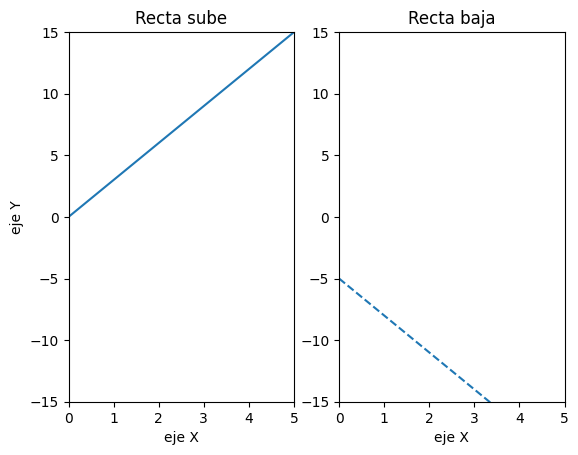

```python
x = np.linspace(0,5,50)
recta_1 = 3*x
recta_2 = -3*x -5
#ej del 1 al 4
fig = plt.figure()
plt.subplot(1,2,1)
plt.plot(x,recta_1,"-")
plt.xlim(0,5)
plt.ylim(-15,15)
plt.title("Recta sube")
plt.ylabel("eje Y")
plt.xlabel("eje X")
plt.subplot(1,2,2)
plt.plot(x,recta_2,"--")
plt.title("Recta baja")
plt.xlim(0,5)
plt.ylim(-15,15)
plt.xlabel("eje X")
```

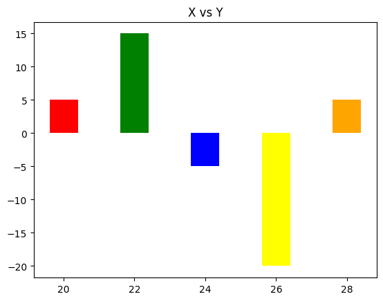

```python
x = [20,22,24,26,28]
y = [5,15,-5,-20,5]
colores = ["red", "green", "blue", "yellow", "orange"]

plt.bar(x,y,color=colores)


plt.title('X vs Y')


plt.show()
```

7. Crea un gráfico de barras. Pintamos la altura de un grupo de amigos, cada barra representa a una persona. Ana mide 160 cm, Luis mide 180 cm, Pedro mide 175 cm, Sofía mide 190 cm, Carmen mide 170 cm. Las barras serán verdes. Consejo: si no vas a tener que manipular especialmente los ejes, es más sencillo dejarlos dentro de la figura.

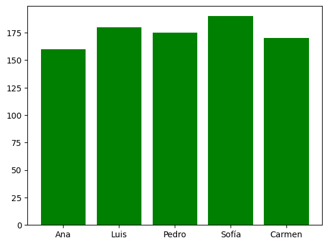

```python
alturas = [160, 180, 175, 190, 170]
nombres =["Ana", "Luis", "Pedro", "Sofía","Carmen"]
plt.bar(nombres, alturas, color="green");
```

[output not shown]

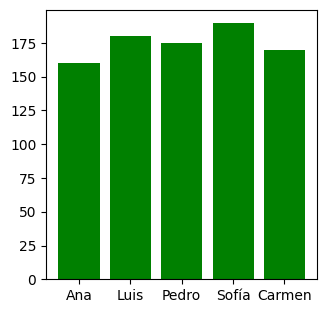

```python
alturas = [160, 180, 175, 190, 170]
nombres =["Ana", "Luis", "Pedro", "Sofía","Carmen"]
plt.figure(figsize=(3.5,3.5)) #llamada a figure antes del grafico
plt.bar(nombres, alturas, color="green");
```

9. Basándote en el gráfico anterior, borra la escala del eje Y (ya aparece en la altura) Pista: cuando plt.yticks() recibe una lista vacía no pinta el eje Y

```python
alturas = [160, 180, 175, 190, 170]
nombres =["Ana", "Luis", "Pedro", "Sofía","Carmen"]
plt.figure(figsize=(3.5,3.5)) #llamada a figure antes del grafico
plt.bar(nombres, alturas, color="green");
```

[output not shown]

10. Prueba a hacer el gráfico con las barras en horizontal.

```python
alturas = [160, 180, 175, 190, 170]
nombres =["Ana", "Luis", "Pedro", "Sofía","Carmen"]
plt.figure(figsize=(3.5,3.5)) #llamada a figure antes del grafico
plt.bar(nombres, alturas, color="green");
```

[output not shown]

11. Prueba a invertir los ejes con ax.invert_axis() Necesitarás tener los ejes disponibles fuera de la figura
12. En el último gráfico, cambia el estilo a 'dark_background'
13. Vamos a introducir pandas. Crea un DataFrame con las columnas "Year" de valores 2015, 2016, 2017, 2018, 2019 y la columna "Sold_items_A" de valores 1000, 3500, 4000, 5500, 7000
14. Ahora pintamos un gráfico de línea con las ventas respecto al año. Pon un título y etiquetas en los ejes. Cambia el estilo a 'seaborn-white'. La línea debe ser con rayas y verde.
15. Otro departamento B ha vendido en esos años 2000, 3100, 5000, 4000, 6000 unidades. Incluye esa columna en el DataFrame y pinta en la misma gráfica las dos líneas. B es una línea punteada y roja. Muestra una leyenda abajo a la derecha.
16. Haz un scatter del departamento A usando **solo el DataFrame**. Pista: el propio DataFrame tiene un método plot. df.plot('columna X', 'columna Y', 'kind' = 'scatter)
17. Prueba a cambiar kind a 'pie'
18. Prueba a quitar la leyenda incluyendo legend igual a False, añade labels y quita la etiqueta en Y
19. Vamos a pintar un histograma de unas alturas generadas aleatoriamente. Crea 300 alturas entre 150 y 190 cm.

Pista: https://pandas.pydata.org/pandas-docs/version/0.23.4/generated/pandas.DataFrame.plot.html